```python
import pandas as pd
import numpy as np
import matplotlib.pyplot as plt
import seaborn as sns
from sklearn import preprocessing as p
from sklearn.linear_model import LinearRegression
from sklearn.model_selection import train_test_split
from sklearn.metrics import r2_score, mean_squared_error
import statsmodels.api as sm
from scipy import stats


%matplotlib inline
```

# Background Information: Domain Knowledge and Information Sources

Most of us have stayed at an Airbnb, right? Some have beeen cheap but some have been freakingly expensive.

What drives the price of an Airbnb? This is what we'll find out in this notebook.

We found some data gold in the form of this Kaggle Airbnb Boston dataset ([link](https://www.kaggle.com/airbnb/boston))

From their own description: The following Airbnb activity is included in this Boston dataset: *Listings, including full descriptions and average review score* Reviews, including unique id for each reviewer and detailed comments * Calendar, including listing id and the price and availability for that day

## Questions to be answered

> How do price vary in the different neighborhoods?

> What elements are correleated with price?

> What's the impact on price of for example, # guests to accomodate, number of ratings, rating, etc?

# Data Understanding & Exploration

### Listings

```python
listings = pd.read_csv('listings.csv')
listings.sample(2)
```

|  | id | listing_url | scrape_id | last_scraped | name | summary | space | description | experiences_offered | neighborhood_overview | ... | review_scores_value | requires_license | license | jurisdiction_names | instant_bookable | cancellation_policy | require_guest_profile_picture | require_guest_phone_verification | calculated_host_listings_count | reviews_per_month |
| --- | --- | --- | --- | --- | --- | --- | --- | --- | --- | --- | --- | --- | --- | --- | --- | --- | --- | --- | --- | --- | --- |
| 2751 | 10381729 | https://www.airbnb.com/rooms/10381729 | 20160906204935 | 2016-09-07 | Nice apartment with open floor plan | Large 1 bedroom in a spacious and comfortable ... | NaN | Large 1 bedroom in a spacious and comfortable ... | none | NaN | ... | 9.0 | f | NaN | NaN | t | flexible | f | f | 2 | 5.23 |
| 2819 | 9239190 | https://www.airbnb.com/rooms/9239190 | 20160906204935 | 2016-09-07 | Spacious rooms minutes from Ashmont | Large well furnished clean rooms on a quiet si... | NaN | Large well furnished clean rooms on a quiet si... | none | NaN | ... | 9.0 | f | NaN | NaN | f | flexible | f | f | 1 | 1.20 |

2 rows × 95 columns

```python
listings.shape
```

```
(3585, 95)
```

```python
listings.info()
```

```
<class 'pandas.core.frame.DataFrame'>
RangeIndex: 3585 entries, 0 to 3584
Data columns (total 95 columns):
id                                  3585 non-null int64
listing_url                         3585 non-null object
scrape_id                           3585 non-null int64
last_scraped                        3585 non-null object
name                                3585 non-null object
summary                             3442 non-null object
space                               2528 non-null object
description                         3585 non-null object
experiences_offered                 3585 non-null object
neighborhood_overview               2170 non-null object
notes                               1610 non-null object
transit                             2295 non-null object
access                              2096 non-null object
interaction                         2031 non-null object
house_rules                         2393 non-null object
thumbnail_url                       2986 non-null object
medium_url                          2986 non-null object
picture_url                         3585 non-null object
xl_picture_url                      2986 non-null object
host_id                             3585 non-null int64
host_url                            3585 non-null object
host_name                           3585 non-null object
host_since                          3585 non-null object
host_location                       3574 non-null object
host_about                          2276 non-null object
host_response_time                  3114 non-null object
host_response_rate                  3114 non-null object
host_acceptance_rate                3114 non-null object
host_is_superhost                   3585 non-null object
host_thumbnail_url                  3585 non-null object
host_picture_url                    3585 non-null object
host_neighbourhood                  3246 non-null object
host_listings_count                 3585 non-null int64
host_total_listings_count           3585 non-null int64
host_verifications                  3585 non-null object
host_has_profile_pic                3585 non-null object
host_identity_verified              3585 non-null object
```

[output cut: 45 more lines]

```
review_scores_checkin               2765 non-null float64
review_scores_communication         2767 non-null float64
review_scores_location              2763 non-null float64
review_scores_value                 2764 non-null float64
requires_license                    3585 non-null object
license                             0 non-null float64
jurisdiction_names                  0 non-null float64
instant_bookable                    3585 non-null object
cancellation_policy                 3585 non-null object
require_guest_profile_picture       3585 non-null object
require_guest_phone_verification    3585 non-null object
calculated_host_listings_count      3585 non-null int64
reviews_per_month                   2829 non-null float64
dtypes: float64(18), int64(15), object(62)
memory usage: 2.6+ MB
```

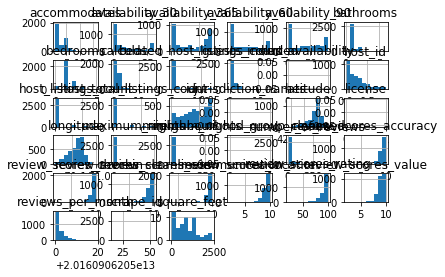

```python
plt.figure(figsize=(14,10))
listings.hist();
```

```python
listings.describe()
```

|  | id | scrape_id | host_id | host_listings_count | host_total_listings_count | neighbourhood_group_cleansed | latitude | longitude | accommodates | bathrooms | ... | review_scores_accuracy | review_scores_cleanliness | review_scores_checkin | review_scores_communication | review_scores_location | review_scores_value | license | jurisdiction_names | calculated_host_listings_count | reviews_per_month |
| --- | --- | --- | --- | --- | --- | --- | --- | --- | --- | --- | --- | --- | --- | --- | --- | --- | --- | --- | --- | --- | --- |
| count | 3.585000e+03 | 3.585000e+03 | 3.585000e+03 | 3585.000000 | 3585.000000 | 0.0 | 3585.000000 | 3585.000000 | 3585.000000 | 3571.000000 | ... | 2762.000000 | 2767.000000 | 2765.000000 | 2767.000000 | 2763.000000 | 2764.000000 | 0.0 | 0.0 | 3585.000000 | 2829.000000 |
| mean | 8.440875e+06 | 2.016091e+13 | 2.492311e+07 | 58.902371 | 58.902371 | NaN | 42.340032 | -71.084818 | 3.041283 | 1.221647 | ... | 9.431571 | 9.258041 | 9.646293 | 9.646549 | 9.414043 | 9.168234 | NaN | NaN | 12.733891 | 1.970908 |
| std | 4.500787e+06 | 8.516813e-01 | 2.292781e+07 | 171.119663 | 171.119663 | NaN | 0.024403 | 0.031565 | 1.778929 | 0.501487 | ... | 0.931863 | 1.168977 | 0.762753 | 0.735507 | 0.903436 | 1.011116 | NaN | NaN | 29.415076 | 2.120561 |
| min | 3.353000e+03 | 2.016091e+13 | 4.240000e+03 | 0.000000 | 0.000000 | NaN | 42.235942 | -71.171789 | 1.000000 | 0.000000 | ... | 2.000000 | 2.000000 | 2.000000 | 4.000000 | 2.000000 | 2.000000 | NaN | NaN | 1.000000 | 0.010000 |
| 25% | 4.679319e+06 | 2.016091e+13 | 6.103425e+06 | 1.000000 | 1.000000 | NaN | 42.329995 | -71.105083 | 2.000000 | 1.000000 | ... | 9.000000 | 9.000000 | 9.000000 | 9.000000 | 9.000000 | 9.000000 | NaN | NaN | 1.000000 | 0.480000 |
| 50% | 8.577620e+06 | 2.016091e+13 | 1.928100e+07 | 2.000000 | 2.000000 | NaN | 42.345201 | -71.078429 | 2.000000 | 1.000000 | ... | 10.000000 | 10.000000 | 10.000000 | 10.000000 | 10.000000 | 9.000000 | NaN | NaN | 2.000000 | 1.170000 |
| 75% | 1.278953e+07 | 2.016091e+13 | 3.622147e+07 | 7.000000 | 7.000000 | NaN | 42.354685 | -71.062155 | 4.000000 | 1.000000 | ... | 10.000000 | 10.000000 | 10.000000 | 10.000000 | 10.000000 | 10.000000 | NaN | NaN | 6.000000 | 2.720000 |
| max | 1.493346e+07 | 2.016091e+13 | 9.385411e+07 | 749.000000 | 749.000000 | NaN | 42.389982 | -71.000100 | 16.000000 | 6.000000 | ... | 10.000000 | 10.000000 | 10.000000 | 10.000000 | 10.000000 | 10.000000 | NaN | NaN | 136.000000 | 19.150000 |

8 rows × 33 columns

### Reviews and Calendar

```python
calendar = pd.read_csv('calendar.csv')
reviews = pd.read_csv('reviews.csv')

reviews.sample(2)
```

|  | listing_id | id | date | reviewer_id | reviewer_name | comments |
| --- | --- | --- | --- | --- | --- | --- |
| 58682 | 8302844 | 78071415 | 2016-06-05 | 53333076 | Ryan | Amazing location! The place is awesome and uni... |
| 5890 | 2308630 | 17380013 | 2014-08-11 | 11799376 | Claire | If you are coming to Boston- this is the only ... |

```python
calendar.sample(2)
```

[output not shown]

|  | listing_id | date | available | price |
| --- | --- | --- | --- | --- |
| 1045243 | 1321422 | 2016-12-20 | f | NaN |
| 1024428 | 7274342 | 2017-06-27 | f | NaN |

```python
reviews.shape, calendar.shape
```

```
((68275, 6), (1308890, 4))
```

```python
calendar.available.value_counts()
```

```
f    665853
t    643037
Name: available, dtype: int64
```

```python
listings.sample()
```

|  | id | listing_url | scrape_id | last_scraped | name | summary | space | description | experiences_offered | neighborhood_overview | ... | review_scores_value | requires_license | license | jurisdiction_names | instant_bookable | cancellation_policy | require_guest_profile_picture | require_guest_phone_verification | calculated_host_listings_count | reviews_per_month |
| --- | --- | --- | --- | --- | --- | --- | --- | --- | --- | --- | --- | --- | --- | --- | --- | --- | --- | --- | --- | --- | --- |
| 2110 | 10295349 | https://www.airbnb.com/rooms/10295349 | 20160906204935 | 2016-09-07 | 1 min walk to T, 15 mins to Boston | This is furnished rooms and can hold up to 10 ... | NaN | This is furnished rooms and can hold up to 10 ... | none | NaN | ... | 6.0 | f | NaN | NaN | f | strict | f | f | 2 | 0.67 |

1 rows × 95 columns

```python
listings.cancellation_policy.value_counts()
```

```
strict             1582
flexible            999
moderate            919
super_strict_30      85
Name: cancellation_policy, dtype: int64
```

```python
listings.requires_license[:5]
```

```
0    f
1    f
2    f
3    f
4    f
Name: requires_license, dtype: object
```

```python
for col in listings.columns:
    print("{}: {}".format(col, listings.loc[2110,col]))
```

```
id: 10295349
listing_url: https://www.airbnb.com/rooms/10295349
scrape_id: 20160906204935
last_scraped: 2016-09-07
name: 1 min walk to T, 15 mins to Boston
summary: This is furnished rooms and can hold up to 10 guests for whole 4 bedroom apt. Walk 1 minutes to subway station and beach. Take subway 10 minutes to airport and 15 minutes to downtown Boston.
space: nan
description: This is furnished rooms and can hold up to 10 guests for whole 4 bedroom apt. Walk 1 minutes to subway station and beach. Take subway 10 minutes to airport and 15 minutes to downtown Boston.
experiences_offered: none
neighborhood_overview: nan
notes: nan
transit: nan
access: nan
interaction: nan
house_rules: nan
thumbnail_url: https://a2.muscache.com/im/pictures/89027c32-217a-4ccf-ba32-203ce2d0e098.jpg?aki_policy=small
medium_url: https://a2.muscache.com/im/pictures/89027c32-217a-4ccf-ba32-203ce2d0e098.jpg?aki_policy=medium
picture_url: https://a2.muscache.com/im/pictures/89027c32-217a-4ccf-ba32-203ce2d0e098.jpg?aki_policy=large
xl_picture_url: https://a2.muscache.com/im/pictures/89027c32-217a-4ccf-ba32-203ce2d0e098.jpg?aki_policy=x_large
host_id: 16938558
host_url: https://www.airbnb.com/users/show/16938558
host_name: Rex
host_since: 2014-06-18
host_location: Boston, Massachusetts, United States
host_about: nan
host_response_time: within a few hours
host_response_rate: 97%
host_acceptance_rate: 63%
host_is_superhost: f
host_thumbnail_url: https://a2.muscache.com/im/pictures/c64d7ee9-df4f-40bb-a2ab-354612609a4b.jpg?aki_policy=profile_small
host_picture_url: https://a2.muscache.com/im/pictures/c64d7ee9-df4f-40bb-a2ab-354612609a4b.jpg?aki_policy=profile_x_medium
host_neighbourhood: Downtown
host_listings_count: 2
host_total_listings_count: 2
host_verifications: ['email', 'phone', 'reviews', 'jumio']
host_has_profile_pic: t
host_identity_verified: t
street: State Street, Boston, MA 02109, United States
neighbourhood: Downtown
neighbourhood_cleansed: Downtown
```

[output cut: 40 more lines]

```
review_scores_accuracy: 6.0
review_scores_cleanliness: 6.0
review_scores_checkin: 6.0
review_scores_communication: 8.0
review_scores_location: 6.0
review_scores_value: 6.0
requires_license: f
license: nan
jurisdiction_names: nan
instant_bookable: f
cancellation_policy: strict
require_guest_profile_picture: f
require_guest_phone_verification: f
calculated_host_listings_count: 2
reviews_per_month: 0.67
```

# Data Wranglig, cleaning, and preparation

Listings

> Some columns may not be so relevant

> More cities than just Boston included

> Amenities: all included as a list

> missing values in many columns and rows

> host_listings_count, host_total_listings_count, accommodates, bathrooms as float instead of int

> Price as string (includes dollar sign)

> Response time is string and not float

## Reducing our dataset - Which columns do we care about?

If our objective is to understand better the price, there are some columns that may not be very helpful in this (e.g. listing_url). A smaller dataset will be better for us to work with

### Columns to keep

I went through all columns, saw what type of values there were and exercised my human judgement to keep only a subset of the columns

Columns to keep:

id summary host_since host_response_time host_response_rate host_acceptance_rate host_is_superhost host_neighbourhood host_identity_verified city zipcode property_type room_type accommodates bathrooms bedrooms beds price security_deposit cleaning_fee extra_people minimum_nights number_of_reviews review_scores_rating instant_bookable cancellation_policy

```python
colss = input("string")
colss = colss.split()
strii = ""
for col in colss:
    strii = strii + "\'" + col + "\', "
print(strii)
```

```
stringid summary host_since host_response_time host_response_rate host_acceptance_rate host_is_superhost host_neighbourhood host_identity_verified city zipcode property_type room_type accommodates bathrooms bedrooms beds price security_deposit cleaning_fee extra_people minimum_nights number_of_revie…
'id', 'summary', 'host_since', 'host_response_time', 'host_response_rate', 'host_acceptance_rate', 'host_is_superhost', 'host_neighbourhood', 'host_identity_verified', 'city', 'zipcode', 'property_type', 'room_type', 'accommodates', 'bathrooms', 'bedrooms', 'beds', 'price', 'security_deposit', 'clea…
```

```python
cols_keep = ['id', 'summary', 'host_response_time', 'host_response_rate', 'host_acceptance_rate', 'host_is_superhost', 'host_neighbourhood', 'host_identity_verified', 'property_type', 'room_type', 'accommodates', 'bathrooms', 'bedrooms', 'beds', 'price', 'security_deposit', 'cleaning_fee', 'extra_people', 'minimum_nights', 'number_of_reviews', 'review_scores_rating', 'instant_bookable', 'cancellation_policy']
cols_keep
```

```
['id',
 'summary',
 'host_response_time',
 'host_response_rate',
 'host_acceptance_rate',
 'host_is_superhost',
 'host_neighbourhood',
 'host_identity_verified',
 'property_type',
 'room_type',
 'accommodates',
 'bathrooms',
 'bedrooms',
 'beds',
 'price',
 'security_deposit',
 'cleaning_fee',
 'extra_people',
 'minimum_nights',
 'number_of_reviews',
 'review_scores_rating',
 'instant_bookable',
 'cancellation_policy']
```

```python
listings_s = listings.copy()
```

```python
listings_s = listings_s[cols_keep]
listings_s.shape
```

```
(3585, 23)
```

```python
listings_s.info()
```

```
<class 'pandas.core.frame.DataFrame'>
RangeIndex: 3585 entries, 0 to 3584
Data columns (total 23 columns):
id                        3585 non-null int64
summary                   3442 non-null object
host_response_time        3114 non-null object
host_response_rate        3114 non-null object
host_acceptance_rate      3114 non-null object
host_is_superhost         3585 non-null object
host_neighbourhood        3246 non-null object
host_identity_verified    3585 non-null object
property_type             3582 non-null object
room_type                 3585 non-null object
accommodates              3585 non-null int64
bathrooms                 3571 non-null float64
bedrooms                  3575 non-null float64
beds                      3576 non-null float64
price                     3585 non-null object
security_deposit          1342 non-null object
cleaning_fee              2478 non-null object
extra_people              3585 non-null object
minimum_nights            3585 non-null int64
number_of_reviews         3585 non-null int64
review_scores_rating      2772 non-null float64
instant_bookable          3585 non-null object
cancellation_policy       3585 non-null object
dtypes: float64(4), int64(4), object(15)
memory usage: 644.3+ KB
```

```python
listings_s.describe()
```

|  | id | accommodates | bathrooms | bedrooms | beds | minimum_nights | number_of_reviews | review_scores_rating |
| --- | --- | --- | --- | --- | --- | --- | --- | --- |
| count | 3.585000e+03 | 3585.000000 | 3571.000000 | 3575.000000 | 3576.000000 | 3585.000000 | 3585.000000 | 2772.000000 |
| mean | 8.440875e+06 | 3.041283 | 1.221647 | 1.255944 | 1.609060 | 3.171269 | 19.044630 | 91.916667 |
| std | 4.500787e+06 | 1.778929 | 0.501487 | 0.753060 | 1.011745 | 8.874133 | 35.571658 | 9.531686 |
| min | 3.353000e+03 | 1.000000 | 0.000000 | 0.000000 | 0.000000 | 1.000000 | 0.000000 | 20.000000 |
| 25% | 4.679319e+06 | 2.000000 | 1.000000 | 1.000000 | 1.000000 | 1.000000 | 1.000000 | 89.000000 |
| 50% | 8.577620e+06 | 2.000000 | 1.000000 | 1.000000 | 1.000000 | 2.000000 | 5.000000 | 94.000000 |
| 75% | 1.278953e+07 | 4.000000 | 1.000000 | 2.000000 | 2.000000 | 3.000000 | 21.000000 | 98.250000 |
| max | 1.493346e+07 | 16.000000 | 6.000000 | 5.000000 | 16.000000 | 300.000000 | 404.000000 | 100.000000 |

Making price an numeric value

```python
listings_s.price = listings_s['price'].replace("$","")
```

```python
no_usd = lambda x: x[1:]
```

```python
listings_s.price = listings_s.price.apply(no_usd)
```

```python
no_commas = lambda x: x.replace(',','')
listings_s.price = listings_s.price.apply(no_commas)
```

```python
listings_s.price[793]
```

```
'1400.00'
```

```python
listings_s.price = pd.to_numeric(listings_s.price)
```

```python
listings_s.price.describe()
```

```
count    3585.000000
mean      173.925802
std       148.331321
min        10.000000
25%        85.000000
50%       150.000000
75%       220.000000
max      4000.000000
Name: price, dtype: float64
```

```python
listings_s.describe()
```

|  | id | accommodates | bathrooms | bedrooms | beds | price | minimum_nights | number_of_reviews | review_scores_rating |
| --- | --- | --- | --- | --- | --- | --- | --- | --- | --- |
| count | 3.585000e+03 | 3585.000000 | 3571.000000 | 3575.000000 | 3576.000000 | 3585.000000 | 3585.000000 | 3585.000000 | 2772.000000 |
| mean | 8.440875e+06 | 3.041283 | 1.221647 | 1.255944 | 1.609060 | 173.925802 | 3.171269 | 19.044630 | 91.916667 |
| std | 4.500787e+06 | 1.778929 | 0.501487 | 0.753060 | 1.011745 | 148.331321 | 8.874133 | 35.571658 | 9.531686 |
| min | 3.353000e+03 | 1.000000 | 0.000000 | 0.000000 | 0.000000 | 10.000000 | 1.000000 | 0.000000 | 20.000000 |
| 25% | 4.679319e+06 | 2.000000 | 1.000000 | 1.000000 | 1.000000 | 85.000000 | 1.000000 | 1.000000 | 89.000000 |
| 50% | 8.577620e+06 | 2.000000 | 1.000000 | 1.000000 | 1.000000 | 150.000000 | 2.000000 | 5.000000 | 94.000000 |
| 75% | 1.278953e+07 | 4.000000 | 1.000000 | 2.000000 | 2.000000 | 220.000000 | 3.000000 | 21.000000 | 98.250000 |
| max | 1.493346e+07 | 16.000000 | 6.000000 | 5.000000 | 16.000000 | 4000.000000 | 300.000000 | 404.000000 | 100.000000 |

```python
listings_s.security_deposit.value_counts()
```

```
$100.00      299
$500.00      228
$200.00      178
$300.00      133
$250.00      107
$400.00       90
$150.00       80
$1,000.00     53
$95.00        41
$350.00       19
$99.00        12
$600.00        9
$1,500.00      9
$450.00        8
$199.00        8
$800.00        7
$125.00        6
$180.00        5
$750.00        5
$275.00        3
$2,500.00      2
$950.00        2
$120.00        2
$1,250.00      2
$4,000.00      2
$2,000.00      2
$375.00        2
$325.00        2
$3,000.00      1
$475.00        1
$307.00        1
$700.00        1
$425.00        1
$160.00        1
$128.00        1
$4,500.00      1
$1,900.00      1
$650.00        1
$1,200.00      1
$299.00        1
$301.00        1
$240.00        1
$223.00        1
$175.00        1
$399.00        1
$446.00        1
$900.00        1
$179.00        1
$330.00        1
$298.00        1
$147.00        1
$185.00        1
$220.00        1
$118.00        1
Name: security_deposit, dtype: int64
```

```python
listings_s.security_deposit = listings_s.security_deposit.fillna('$0')
listings_s.security_deposit = listings_s.security_deposit.apply(no_usd)
```

```python
listings_s.security_deposit.describe()
```

```
count     3585
unique      55
top          0
freq      2243
Name: security_deposit, dtype: object
```

```python
listings_s.security_deposit = listings_s.security_deposit.apply(no_commas)
```

```python
listings_s.security_deposit = pd.to_numeric(listings_s.security_deposit)
```

```python
listings_s.security_deposit.describe()
```

```
count    3585.000000
mean      121.546722
std       255.279878
min         0.000000
25%         0.000000
50%         0.000000
75%       179.000000
max      4500.000000
Name: security_deposit, dtype: float64
```

Oh no! This is not sustainable. There are also other columns with $ signs. might as well create a function

```python
def clean_usd(df,col_name):
    '''
    INPUT
    - df : Data Frame
    - col_name (string): Column name to be clean. Should be for cols that follow this format $100.08

    PROCESS
    - Fill na with string $0
    - remove $ sign
    - remove commas
    - convert to numeric

    OUTPUT
    - Clean df: Column Float with numeric value. Any NAs will be filled with 0

    '''
    import pandas as pd

    #Fill na with string $0
    df[col_name] = df[col_name].fillna('$0')

    #remove $ sign
    no_usd = lambda x: x[1:]
    df[col_name] = df[col_name].apply(no_usd)

    #remove commas
    no_commas = lambda x: x.replace(',','')
    df[col_name] = df[col_name].apply(no_commas)

    #convert to numeric
    df[col_name] = pd.to_numeric(df[col_name])

    return df
```

```python
listings_s.extra_people[:3]
```

```
0     $0.00
1     $0.00
2    $20.00
Name: extra_people, dtype: object
```

```python
listings_s = clean_usd(listings_s,'extra_people')
```

```python
listings_s = clean_usd(listings_s,'cleaning_fee')
```

```python
listings_s.cleaning_fee[:3]
```

```
0    35.0
1    10.0
2     0.0
Name: cleaning_fee, dtype: float64
```

#### Remove percentages

```python
listings_s.host_acceptance_rate.isnull().sum()
```

```
471
```

```python
type(listings_s.host_response_rate[3561]) == float
```

```
True
```

```python
type(listings_s.host_response_rate[3]) == str
```

```
True
```

```python
listings_s.host_response_rate = listings_s.host_response_rate.astype(str)
```

```python
listings_s.host_response_rate = listings_s.host_response_rate.apply(lambda x: np.nan if x == 'nan' else x[:-1]).astype(float)/100
```

```python
listings_s.host_acceptance_rate = listings_s.host_acceptance_rate.astype(str)
listings_s.host_acceptance_rate = listings_s.host_acceptance_rate.apply(lambda x: np.nan if x == 'nan' else x[:-1]).astype(float)/100
```

```python
listings_s.host_acceptance_rate.describe()
```

```
count    3114.000000
mean        0.841731
std         0.217793
min         0.000000
25%         0.710000
50%         0.940000
75%         1.000000
max         1.000000
Name: host_acceptance_rate, dtype: float64
```

```python
listings_s.host_response_rate = listings_s.host_response_rate.astype(str)
```

```python
listings_s.id = listings_s.id.astype(float)
```

### Imputing missing values

```python
listings_s.summary = listings_s.summary.fillna('none')
```

```python
listings_s.host_response_time = listings_s.host_response_time.fillna('within a day')
```

```python
listings_s.host_response_rate = listings_s.host_response_rate.astype(float)
```

```python
listings_s.host_acceptance_rate = listings_s.host_acceptance_rate.fillna(listings_s.host_acceptance_rate.mean())
```

```python
listings_s.host_neighbourhood = listings_s.host_neighbourhood.fillna('other')
```

```python
type(listings_s.host_response_rate[3])
```

```
numpy.float64
```

```python
listings_s.host_response_rate = listings_s.host_response_rate.astype(float)
```

### Remove NAs

```python
listings_ss = listings_s.copy()
```

```python
listings_ss
```

|  | id | summary | host_response_time | host_response_rate | host_acceptance_rate | host_is_superhost | host_neighbourhood | host_identity_verified | property_type | room_type | ... | beds | price | security_deposit | cleaning_fee | extra_people | minimum_nights | number_of_reviews | review_scores_rating | instant_bookable | cancellation_policy |
| --- | --- | --- | --- | --- | --- | --- | --- | --- | --- | --- | --- | --- | --- | --- | --- | --- | --- | --- | --- | --- | --- |
| 0 | 12147973.0 | Cozy, sunny, family home. Master bedroom high... | within a day | NaN | 0.841731 | f | Roslindale | f | House | Entire home/apt | ... | 3.0 | 250.0 | 0.0 | 35.0 | 0.0 | 2 | 0 | NaN | f | moderate |
| 1 | 3075044.0 | Charming and quiet room in a second floor 1910... | within an hour | 1.00 | 1.000000 | f | Roslindale | t | Apartment | Private room | ... | 1.0 | 65.0 | 95.0 | 10.0 | 0.0 | 2 | 36 | 94.0 | t | moderate |
| 2 | 6976.0 | Come stay with a friendly, middle-aged guy in ... | within a few hours | 1.00 | 0.880000 | t | Roslindale | t | Apartment | Private room | ... | 1.0 | 65.0 | 0.0 | 0.0 | 20.0 | 3 | 41 | 98.0 | f | moderate |
| 3 | 1436513.0 | Come experience the comforts of home away from... | within a few hours | 1.00 | 0.500000 | f | other | f | House | Private room | ... | 2.0 | 75.0 | 100.0 | 50.0 | 25.0 | 1 | 1 | 100.0 | f | moderate |
| 4 | 7651065.0 | My comfy, clean and relaxing home is one block... | within an hour | 1.00 | 1.000000 | t | Roslindale | t | House | Private room | ... | 2.0 | 79.0 | 0.0 | 15.0 | 0.0 | 2 | 29 | 99.0 | f | flexible |
| 5 | 12386020.0 | Super comfy bedroom plus your own bathroom in ... | within a few hours | 1.00 | 0.950000 | t | Roslindale | t | Condominium | Private room | ... | 1.0 | 75.0 | 0.0 | 30.0 | 0.0 | 2 | 8 | 100.0 | f | flexible |
| 6 | 5706985.0 | It's a 5 minute walk to Rosi Square to catch t... | within an hour | 0.98 | 0.960000 | f | Roslindale | t | Apartment | Entire home/apt | ... | 2.0 | 100.0 | 0.0 | 0.0 | 25.0 | 1 | 57 | 90.0 | f | strict |
| 7 | 2843445.0 | We can accommodate guests who are gluten-free,... | within a few hours | 1.00 | 1.000000 | t | Roslindale | t | House | Private room | ... | 1.0 | 75.0 | 0.0 | 10.0 | 15.0 | 1 | 67 | 96.0 | f | moderate |
| 8 | 753446.0 | Nice and cozy apartment about 6 miles away to ... | within an hour | 1.00 | 1.000000 | t | Roslindale | t | Condominium | Private room | ... | 2.0 | 58.0 | 0.0 | 0.0 | 0.0 | 2 | 65 | 96.0 | f | moderate |
| 9 | 849408.0 | This is a cozy and spacious two bedroom unit w... | within an hour | 1.00 | 1.000000 | t | Roslindale | t | Apartment | Entire home/apt | ... | 2.0 | 229.0 | 200.0 | 50.0 | 25.0 | 4 | 33 | 94.0 | f | strict |
| 10 | 12023024.0 | The room is in a single family house located i... | within a day | 0.83 | 1.000000 | f | Roslindale | f | House | Private room | ... | 1.0 | 60.0 | 0.0 | 30.0 | 10.0 | 1 | 1 | 80.0 | f | flexible |
| 11 | 1668313.0 | Quiet second floor bedroom sleeps one in comfo... | within an hour | 1.00 | 0.890000 | t | Roslindale | t | House | Private room | ... | 1.0 | 57.0 | 0.0 | 40.0 | 0.0 | 1 | 17 | 94.0 | f | flexible |
| 12 | 2684840.0 | Clean, sunny 2 bedroom in amazing Roslindale V... | within a few hours | 1.00 | 1.000000 | f | Roslindale | f | Condominium | Entire home/apt | ... | 2.0 | 93.0 | 0.0 | 40.0 | 0.0 | 1 | 1 | 100.0 | t | flexible |
| 13 | 13547301.0 | My place is close to Public Transportation. Th... | within an hour | 1.00 | 0.970000 | f | Roslindale | t | Apartment | Entire home/apt | ... | 3.0 | 150.0 | 0.0 | 50.0 | 30.0 | 2 | 12 | 97.0 | f | moderate |
| 14 | 5434353.0 | Enjoy the full space of our home as you explor... | within a day | 0.75 | 1.000000 | f | Roslindale | t | House | Entire home/apt | ... | 2.0 | 145.0 | 500.0 | 150.0 | 35.0 | 3 | 7 | 91.0 | f | moderate |
| 15 | 225979.0 | Fresh home roasted coffee from around the worl... | within an hour | 1.00 | 0.790000 | f | Roslindale | f | Apartment | Private room | ... | 1.0 | 60.0 | 0.0 | 0.0 | 0.0 | 1 | 70 | 96.0 | t | strict |
| 16 | 3420384.0 | Located along public transportation with plent... | within a few hours | 1.00 | 1.000000 | f | Roslindale | f | House | Private room | ... | 3.0 | 165.0 | 0.0 | 50.0 | 15.0 | 3 | 1 | 100.0 | f | flexible |
| 17 | 13512930.0 | Clean, sunny 1 bedroom in amazing Roslindale V... | within a few hours | 1.00 | 1.000000 | f | Roslindale | f | Condominium | Private room | ... | 1.0 | 75.0 | 0.0 | 20.0 | 15.0 | 1 | 1 | 100.0 | t | flexible |
| 18 | 7482195.0 | A handsome colonial house set on a tranquil si... | within a day | 1.00 | 1.000000 | t | Roslindale | t | House | Private room | ... | 1.0 | 49.0 | 0.0 | 0.0 | 10.0 | 5 | 0 | NaN | f | strict |
| 19 | 7252607.0 | A handsome colonial house set on a tranquil si... | within a day | 1.00 | 1.000000 | t | Roslindale | t | House | Private room | ... | 1.0 | 49.0 | 0.0 | 0.0 | 10.0 | 5 | 4 | 95.0 | f | strict |
| 20 | 2583074.0 | My home is a villa in one of the friendliest, ... | within a few hours | 1.00 | 0.940000 | t | Roslindale | t | Villa | Private room | ... | 1.0 | 40.0 | 0.0 | 0.0 | 0.0 | 2 | 31 | 99.0 | f | flexible |
| 21 | 13251243.0 | Lovely sun-filled private guest cottage set on... | within an hour | 1.00 | 1.000000 | f | Roslindale | t | House | Entire home/apt | ... | 2.0 | 120.0 | 150.0 | 50.0 | 0.0 | 2 | 16 | 98.0 | t | moderate |
| 22 | 225834.0 | High atop Metropolitan Hill. Expansive view. N... | within an hour | 1.00 | 0.790000 | f | Roslindale | f | Apartment | Private room | ... | 1.0 | 70.0 | 0.0 | 0.0 | 10.0 | 1 | 38 | 98.0 | t | strict |
| 23 | 6400432.0 | Three bedroom in Boston's Roslindale neighborh... | within a day | 1.00 | 0.630000 | f | other | t | House | Entire home/apt | ... | 5.0 | 150.0 | 150.0 | 100.0 | 0.0 | 3 | 21 | 88.0 | f | flexible |
| 24 | 5498472.0 | Our spacious, modern, immaculate town home is ... | within a day | NaN | 0.841731 | f | Roslindale | f | House | Entire home/apt | ... | 3.0 | 175.0 | 500.0 | 100.0 | 0.0 | 14 | 1 | 100.0 | f | moderate |
| 25 | 894539.0 | none | within an hour | 1.00 | 0.920000 | t | Roslindale | t | House | Private room | ... | 1.0 | 95.0 | 0.0 | 10.0 | 0.0 | 1 | 40 | 96.0 | f | moderate |
| 26 | 879929.0 | none | within an hour | 1.00 | 1.000000 | f | Roslindale | f | Apartment | Private room | ... | 1.0 | 90.0 | 0.0 | 0.0 | 0.0 | 1 | 43 | 95.0 | f | strict |
| 27 | 9218312.0 | Located in the Peter's Hill neighborhood, rest... | within a few hours | 1.00 | 1.000000 | t | Roslindale | t | House | Private room | ... | 1.0 | 95.0 | 0.0 | 15.0 | 0.0 | 2 | 33 | 99.0 | f | moderate |
| 28 | 321328.0 | none | within a day | 0.60 | 1.000000 | f | Roslindale | t | Apartment | Private room | ... | 2.0 | 100.0 | 0.0 | 0.0 | 100.0 | 1 | 11 | 90.0 | f | flexible |
| 29 | 1810172.0 | This second floor bedroom sleeps two in a quee... | within an hour | 1.00 | 0.890000 | t | Roslindale | t | House | Private room | ... | 1.0 | 67.0 | 0.0 | 40.0 | 5.0 | 1 | 20 | 96.0 | f | flexible |
| ... | ... | ... | ... | ... | ... | ... | ... | ... | ... | ... | ... | ... | ... | ... | ... | ... | ... | ... | ... | ... | ... |
| 3555 | 13015653.0 | The private room is big enough. My place is 5 ... | within a few hours | 1.00 | 1.000000 | f | Brookline | f | Apartment | Private room | ... | 1.0 | 39.0 | 100.0 | 20.0 | 20.0 | 1 | 4 | 100.0 | f | moderate |
| 3556 | 14849141.0 | 5 min walking to Orange Line subway with 2 sto... | within an hour | 0.96 | 1.000000 | f | Somerville | t | Apartment | Private room | ... | 1.0 | 69.0 | 0.0 | 0.0 | 25.0 | 1 | 0 | NaN | t | strict |
| 3557 | 14604429.0 | My place is close to BU, Brookline (Coolidge C... | within a day | 1.00 | 0.670000 | f | other | f | Apartment | Private room | ... | NaN | 60.0 | 0.0 | 20.0 | 0.0 | 1 | 0 | NaN | f | flexible |
| 3558 | 14592644.0 | Located in very center, between Harvard and MI... | within a few hours | 1.00 | 1.000000 | f | other | t | Apartment | Entire home/apt | ... | 1.0 | 195.0 | 200.0 | 130.0 | 50.0 | 5 | 0 | NaN | f | strict |
| 3559 | 12915510.0 | Our boat is used as a live-aboard and has more... | within a few hours | 1.00 | 0.600000 | f | other | t | Boat | Private room | ... | 5.0 | 229.0 | 500.0 | 100.0 | 50.0 | 2 | 4 | 100.0 | f | moderate |
| 3560 | 14887382.0 | Cozy entire apartment on the ground floor, loc... | within an hour | 0.96 | 1.000000 | f | Somerville | t | Apartment | Entire home/apt | ... | 3.0 | 249.0 | 100.0 | 80.0 | 25.0 | 2 | 0 | NaN | f | strict |
| 3561 | 14823430.0 | My place is close to Brookline Village, Coolid... | within a day | NaN | 0.841731 | f | other | f | Loft | Private room | ... | 2.0 | 72.0 | 0.0 | 0.0 | 10.0 | 1 | 0 | NaN | f | strict |
| 3562 | 14881840.0 | Modern cozy apartment with amazing location ri... | within a day | NaN | 0.841731 | f | other | f | Apartment | Shared room | ... | 1.0 | 179.0 | 0.0 | 0.0 | 0.0 | 1 | 0 | NaN | f | flexible |
| 3563 | 11452297.0 | Newly renovated apartment available: - Updated... | within a day | NaN | 0.841731 | f | Somerville | f | Apartment | Entire home/apt | ... | 3.0 | 199.0 | 200.0 | 0.0 | 0.0 | 2 | 0 | NaN | f | moderate |
| 3564 | 14576706.0 | 5 min walking to Orange Line subway with 2 sto... | within an hour | 0.96 | 1.000000 | f | Somerville | t | Apartment | Private room | ... | 1.0 | 75.0 | 95.0 | 0.0 | 24.0 | 1 | 0 | NaN | t | strict |
| 3565 | 14335003.0 | My place is a block from the Charles River, a ... | within a few hours | 1.00 | 1.000000 | f | other | f | Apartment | Entire home/apt | ... | 2.0 | 146.0 | 0.0 | 0.0 | 0.0 | 4 | 1 | 100.0 | t | flexible |
| 3566 | 14871445.0 | My place is good for couples, solo adventurers... | within an hour | 1.00 | 1.000000 | f | Brookline | t | Apartment | Private room | ... | 1.0 | 85.0 | 0.0 | 0.0 | 0.0 | 1 | 0 | NaN | f | flexible |
| 3567 | 14472678.0 | 3 reasons why you should stay at this Flatbook... | within a few hours | 0.71 | 0.980000 | f | Gay Village | t | Apartment | Entire home/apt | ... | 5.0 | 259.0 | 400.0 | 95.0 | 0.0 | 3 | 0 | NaN | t | strict |
| 3568 | 14574800.0 | 5 min walking to Orange Line subway with 2 sto... | within an hour | 0.96 | 1.000000 | f | Somerville | t | Apartment | Private room | ... | 1.0 | 69.0 | 95.0 | 0.0 | 24.0 | 1 | 1 | 80.0 | t | strict |
| 3569 | 14426586.0 | 1 private BR w/ full size bed and bath + a que... | within an hour | 1.00 | 0.530000 | f | other | f | Apartment | Entire home/apt | ... | 2.0 | 200.0 | 0.0 | 0.0 | 50.0 | 1 | 0 | NaN | f | flexible |
| 3570 | 3131519.0 | Locate at the Green Line subway terminal, walk... | within an hour | 1.00 | 1.000000 | f | East Boston | t | House | Private room | ... | 1.0 | 72.0 | 100.0 | 20.0 | 15.0 | 1 | 8 | 90.0 | f | strict |
| 3571 | 14592547.0 | My place is close to 4Acoffee, Starbucks, Harr... | within an hour | 1.00 | 1.000000 | f | Brookline | f | Apartment | Private room | ... | 1.0 | 89.0 | 0.0 | 0.0 | 0.0 | 1 | 2 | 100.0 | f | flexible |
| 3572 | 14744740.0 | This sunny Cambridge apartment boasts expansiv... | within a few hours | 0.71 | 0.980000 | f | Gay Village | t | Apartment | Entire home/apt | ... | 5.0 | 459.0 | 400.0 | 95.0 | 0.0 | 3 | 0 | NaN | t | strict |
| 3573 | 14504583.0 | My place is close to My home is a warm and fri... | within an hour | 1.00 | 0.950000 | f | Somerville | t | Apartment | Private room | ... | 1.0 | 65.0 | 0.0 | 25.0 | 30.0 | 1 | 2 | 80.0 | t | flexible |
| 3574 | 14743129.0 | 我的房源走路2 minutes有shopping mall,包括CVS,restuarant... | within an hour | 1.00 | 1.000000 | f | Chestnut Hill | f | Townhouse | Private room | ... | 1.0 | 68.0 | 950.0 | 0.0 | 35.0 | 1 | 1 | 80.0 | f | moderate |
| 3575 | 5280827.0 | Cozy room near T station. 5 min walking to T, ... | within an hour | 0.96 | 1.000000 | f | Somerville | t | Apartment | Private room | ... | 1.0 | 69.0 | 95.0 | 0.0 | 24.0 | 2 | 6 | 70.0 | t | strict |
| 3576 | 14689681.0 | You'd be living on the top floor of a four sto... | within a day | 1.00 | 1.000000 | f | Cambridge | t | House | Private room | ... | 1.0 | 124.0 | 200.0 | 85.0 | 0.0 | 2 | 0 | NaN | f | flexible |
| 3577 | 13750763.0 | Our place is close to Coolidge Corner, Allston... | within a day | NaN | 0.841731 | f | Brookline | f | Apartment | Private room | ... | 1.0 | 150.0 | 0.0 | 0.0 | 0.0 | 1 | 0 | NaN | f | flexible |
| 3578 | 14536322.0 | Exquisite garden level (semi basement) room in... | within an hour | 1.00 | 1.000000 | f | other | f | House | Private room | ... | 1.0 | 85.0 | 0.0 | 0.0 | 0.0 | 1 | 2 | 100.0 | t | strict |
| 3579 | 14852179.0 | - Grocery: A full-size Star market is 2 minute... | within a day | NaN | 0.841731 | f | Brookline | t | Condominium | Private room | ... | 1.0 | 100.0 | 0.0 | 10.0 | 0.0 | 2 | 0 | NaN | f | flexible |
| 3580 | 8373729.0 | 5 min walking to Orange Line subway with 2 sto... | within an hour | 0.96 | 1.000000 | f | Somerville | t | Apartment | Private room | ... | 1.0 | 69.0 | 95.0 | 0.0 | 24.0 | 2 | 4 | 90.0 | t | strict |
| 3581 | 14844274.0 | Most popular apartment in BU, best located in ... | a few days or more | 0.10 | 0.830000 | f | other | t | Apartment | Private room | ... | 1.0 | 150.0 | 100.0 | 15.0 | 0.0 | 3 | 0 | NaN | f | strict |
| 3582 | 14585486.0 | Funky little apartment close to public transpo... | within a day | 0.78 | 0.500000 | f | other | f | Apartment | Entire home/apt | ... | 1.0 | 198.0 | 0.0 | 0.0 | 0.0 | 3 | 0 | NaN | f | flexible |
| 3583 | 14603878.0 | My place is close to Taco Loco Mexican Grill, ... | within an hour | 1.00 | 0.960000 | f | Somerville | t | Apartment | Private room | ... | 1.0 | 65.0 | 100.0 | 0.0 | 30.0 | 1 | 2 | 90.0 | f | strict |
| 3584 | 14504422.0 | My place is close to My home is a warm and fri... | within an hour | 1.00 | 0.950000 | f | Somerville | t | Apartment | Private room | ... | 1.0 | 65.0 | 0.0 | 25.0 | 30.0 | 1 | 0 | NaN | t | flexible |

3585 rows × 23 columns

```python
listings_ss.dropna(inplace=True)
listings_ss.shape
```

```
(2529, 23)
```

```python
listings_ss.reset_index(inplace=True)
listings_ss.drop('index',axis=1,inplace=True)
```

Remove negative values

# Modeling

```python
listings_ss.describe()
```

|  | id | host_response_rate | host_acceptance_rate | accommodates | bathrooms | bedrooms | beds | price | security_deposit | cleaning_fee | extra_people | minimum_nights | number_of_reviews | review_scores_rating |
| --- | --- | --- | --- | --- | --- | --- | --- | --- | --- | --- | --- | --- | --- | --- |
| count | 2.529000e+03 | 2529.000000 | 2529.000000 | 2529.000000 | 2529.000000 | 2529.000000 | 2529.000000 | 2529.000000 | 2529.000000 | 2529.000000 | 2529.000000 | 2529.000000 | 2529.000000 | 2529.000000 |
| mean | 7.704755e+06 | 0.956481 | 0.852665 | 3.097272 | 1.218466 | 1.255437 | 1.641756 | 167.514037 | 134.199684 | 48.843416 | 12.471728 | 2.890866 | 26.150257 | 92.081060 |
| std | 4.444218e+06 | 0.107099 | 0.211118 | 1.854484 | 0.505331 | 0.775665 | 1.079775 | 110.638176 | 269.143670 | 52.768946 | 20.064298 | 7.018056 | 39.606195 | 8.955551 |
| min | 3.353000e+03 | 0.000000 | 0.000000 | 1.000000 | 0.000000 | 0.000000 | 0.000000 | 11.000000 | 0.000000 | 0.000000 | 0.000000 | 1.000000 | 1.000000 | 20.000000 |
| 25% | 4.054079e+06 | 0.980000 | 0.770000 | 2.000000 | 1.000000 | 1.000000 | 1.000000 | 85.000000 | 0.000000 | 0.000000 | 0.000000 | 1.000000 | 4.000000 | 89.000000 |
| 50% | 7.823025e+06 | 1.000000 | 0.950000 | 2.000000 | 1.000000 | 1.000000 | 1.000000 | 149.000000 | 0.000000 | 30.000000 | 0.000000 | 2.000000 | 11.000000 | 94.000000 |
| 75% | 1.198354e+07 | 1.000000 | 1.000000 | 4.000000 | 1.000000 | 2.000000 | 2.000000 | 219.000000 | 200.000000 | 80.000000 | 20.000000 | 3.000000 | 31.000000 | 98.000000 |
| max | 1.484378e+07 | 1.000000 | 1.000000 | 16.000000 | 6.000000 | 5.000000 | 16.000000 | 1300.000000 | 4500.000000 | 300.000000 | 200.000000 | 273.000000 | 404.000000 | 100.000000 |

```python
listings_ss.corr()['price']
```

```
id                     -0.112721
host_response_rate      0.000709
host_acceptance_rate   -0.175247
accommodates            0.602881
bathrooms               0.333482
bedrooms                0.562650
beds                    0.525009
price                   1.000000
security_deposit        0.233400
cleaning_fee            0.458788
extra_people            0.046930
minimum_nights         -0.019580
number_of_reviews      -0.120923
review_scores_rating    0.093657
Name: price, dtype: float64
```

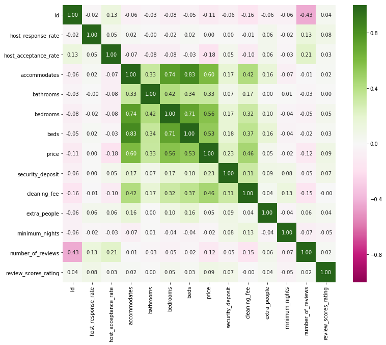

```python
plt.figure(figsize=(12,10))
sns.heatmap(listings_ss.corr(),annot=True,vmin = -1, vmax =1,fmt='.2f',cmap='PiYG');
```

Interesting! Some of the variables more highly correlated with price are cleaning_fee, measures of size (beds, bedrooms, accommodates). Interesting, the number of reviews and the acceptance rate is negatively correlate, whereas the review_scores_rating has almost no correlation to the price.

```python
listings_s.host_neighbourhood.value_counts()
```

```
Allston-Brighton             375
other                        339
Jamaica Plain                319
Back Bay                     312
Fenway/Kenmore               290
South End                    233
Dorchester                   218
South Boston                 198
Beacon Hill                  194
Roxbury                      143
North End                    126
East Boston                  114
Mission Hill                  96
West End                      82
Charlestown                   65
Gay Village                   58
Roslindale                    53
Cambridge                     51
Downtown Crossing             33
West Roxbury                  32
Hyde Park                     31
Theater District              26
Mattapan                      25
Central Business District     25
Somerville                    24
Medford                       20
Upper East Side               13
Chinatown                     13
Financial District            13
Downtown                      12
Brookline                      8
Leather District               8
South Beach                    4
Flatiron District              3
Chestnut Hill                  3
Los Altos Hills                3
Coolidge Corner                2
East Harlem                    2
Chelsea                        2
Belváros                       2
Harvard Square                 2
Miami Beach                    1
South of Nevsky                1
Santa Cruz                     1
Government Center              1
Sunnyvale                      1
Benton Park                    1
Malden                         1
Midtown East                   1
Newton                         1
Mission District               1
Bernal Heights                 1
Winthrop                       1
Coral Way                      1
Name: host_neighbourhood, dtype: int64
```

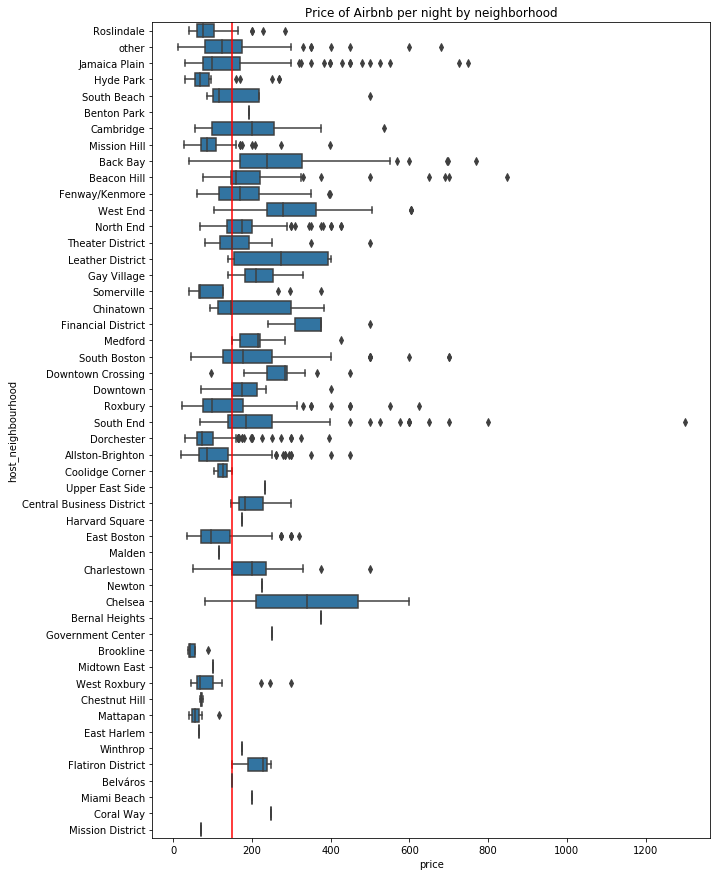

```python
plt.figure(figsize=(10,15))
base_color = sns.color_palette()[0]
sns.boxplot(data=listings_ss,x='price',y='host_neighbourhood',color=base_color)
plt.title('Price of Airbnb per night by neighborhood')
#plt.axvline(listings_ss.price.mean())
plt.axvline(listings_ss.price.median(),color='r');
```

### StandardScaler

I decided not to use the standardscaler - for now. Although it may grant some additional power to our regression, it will make the variables harder to interpret.

```python
num_cols = []
numerics = [np.int64, np.float64]
for col in listings_ss.columns:
    if type(listings_ss[col][100]) in numerics:
        num_cols.append(col)
num_cols.remove('price')
num_cols
```

```
['id',
 'host_response_rate',
 'host_acceptance_rate',
 'accommodates',
 'bathrooms',
 'bedrooms',
 'beds',
 'security_deposit',
 'cleaning_fee',
 'extra_people',
 'minimum_nights',
 'number_of_reviews',
 'review_scores_rating']
```

```python
'''
# Apply feature scaling to the general population demographics data.
scaler = p.StandardScaler()
listings_sca = scaler.fit_transform(listings_ss[num_cols])
listings_sca = pd.DataFrame(listings_sca)
listings_ss[num_cols] = listings_sca
'''
```

## One-hot encoding

```python
listings_one = listings_ss.copy()
```

```python
listings_one.sample()
```

|  | id | summary | host_response_time | host_response_rate | host_acceptance_rate | host_is_superhost | host_neighbourhood | host_identity_verified | property_type | room_type | ... | beds | price | security_deposit | cleaning_fee | extra_people | minimum_nights | number_of_reviews | review_scores_rating | instant_bookable | cancellation_policy |
| --- | --- | --- | --- | --- | --- | --- | --- | --- | --- | --- | --- | --- | --- | --- | --- | --- | --- | --- | --- | --- | --- |
| 581 | 4568116.0 | Private efficient, well-designed micro studio,... | within a few hours | 1.0 | 1.0 | t | Roxbury | t | Apartment | Entire home/apt | ... | 1.0 | 135.0 | 350.0 | 25.0 | 30.0 | 2 | 163 | 96.0 | f | moderate |

1 rows × 23 columns

```python
for col in listings_ss.columns:
    print(type(listings_ss[col][1]))
```

```
<class 'numpy.float64'>
<class 'str'>
<class 'str'>
<class 'numpy.float64'>
<class 'numpy.float64'>
<class 'str'>
<class 'str'>
<class 'str'>
<class 'str'>
<class 'str'>
<class 'numpy.int64'>
<class 'numpy.float64'>
<class 'numpy.float64'>
<class 'numpy.float64'>
<class 'numpy.float64'>
<class 'numpy.float64'>
<class 'numpy.float64'>
<class 'numpy.float64'>
<class 'numpy.int64'>
<class 'numpy.int64'>
<class 'numpy.float64'>
<class 'str'>
<class 'str'>
```

```python
cat_cols = []
cat = [str]
for col in listings_ss.columns:
    if type(listings_ss[col][100]) in cat:
        cat_cols.append(col)
#cat_cols.remove('id')
cat_cols.remove('summary')

cat_cols
```

```
['host_response_time',
 'host_is_superhost',
 'host_neighbourhood',
 'host_identity_verified',
 'property_type',
 'room_type',
 'instant_bookable',
 'cancellation_policy']
```

```python
listings_one = pd.get_dummies(listings_one,columns=cat_cols)
```

```python
listings_one.sample()
```

|  | id | summary | host_response_rate | host_acceptance_rate | accommodates | bathrooms | bedrooms | beds | price | security_deposit | ... | property_type_Villa | room_type_Entire home/apt | room_type_Private room | room_type_Shared room | instant_bookable_f | instant_bookable_t | cancellation_policy_flexible | cancellation_policy_moderate | cancellation_policy_strict | cancellation_policy_super_strict_30 |
| --- | --- | --- | --- | --- | --- | --- | --- | --- | --- | --- | --- | --- | --- | --- | --- | --- | --- | --- | --- | --- | --- |
| 1065 | 13391640.0 | My place is close to Boston Public Garden, Che... | 0.8 | 1.0 | 2 | 1.0 | 0.0 | 1.0 | 200.0 | 95.0 | ... | 0 | 1 | 0 | 0 | 0 | 1 | 1 | 0 | 0 | 0 |

1 rows × 94 columns

```python
for col in listings_one.columns:
    print(col)
```

```
id
summary
host_response_rate
host_acceptance_rate
accommodates
bathrooms
bedrooms
beds
price
security_deposit
cleaning_fee
extra_people
minimum_nights
number_of_reviews
review_scores_rating
host_response_time_a few days or more
host_response_time_within a day
host_response_time_within a few hours
host_response_time_within an hour
host_is_superhost_f
host_is_superhost_t
host_neighbourhood_Allston-Brighton
host_neighbourhood_Back Bay
host_neighbourhood_Beacon Hill
host_neighbourhood_Belváros
host_neighbourhood_Benton Park
host_neighbourhood_Bernal Heights
host_neighbourhood_Brookline
host_neighbourhood_Cambridge
host_neighbourhood_Central Business District
host_neighbourhood_Charlestown
host_neighbourhood_Chelsea
host_neighbourhood_Chestnut Hill
host_neighbourhood_Chinatown
host_neighbourhood_Coolidge Corner
host_neighbourhood_Coral Way
host_neighbourhood_Dorchester
host_neighbourhood_Downtown
host_neighbourhood_Downtown Crossing
host_neighbourhood_East Boston
```

[output cut: 39 more lines]

```
property_type_Guesthouse
property_type_House
property_type_Loft
property_type_Other
property_type_Townhouse
property_type_Villa
room_type_Entire home/apt
room_type_Private room
room_type_Shared room
instant_bookable_f
instant_bookable_t
cancellation_policy_flexible
cancellation_policy_moderate
cancellation_policy_strict
cancellation_policy_super_strict_30
```

# Regression

```python
df_reg = listings_one.copy()
```

```python
#no_neg = lambda x: x=0 if x<0

for col in num_cols:
    df_reg[col] = df_reg[col].clip(lower=0)
```

```python
# Apply feature scaling to the general population demographics data.
scaler = p.StandardScaler()
listings_sca = scaler.fit_transform(df_reg[num_cols])
listings_sca = pd.DataFrame(listings_sca)
df_reg[num_cols] = listings_sca
```

```python
df_reg.drop('summary', axis=1, inplace=True)
df_reg.drop('id', axis=1, inplace=True)
```

```python
# Divide into X and Y
y = df_reg.price
X = df_reg.loc[:,df_reg.columns != 'price']
```

```python
len(y), len(X)
```

```
(2529, 2529)
```

```python
# Split into train and test
X_train, X_test, y_train, y_test = train_test_split(X,y,test_size=0.3,random_state=42)
```

```python
# Instantiate model
lm_model = LinearRegression(normalize=True)
```

```python
# Fit model
lm_model.fit(X_train, y_train)
```

```
LinearRegression(copy_X=True, fit_intercept=True, n_jobs=None, normalize=True)
```

```python
y_pred = lm_model.predict(X_test)
```

```python
X_test[:1]
```

|  | host_response_rate | host_acceptance_rate | accommodates | bathrooms | bedrooms | beds | security_deposit | cleaning_fee | extra_people | minimum_nights | ... | property_type_Villa | room_type_Entire home/apt | room_type_Private room | room_type_Shared room | instant_bookable_f | instant_bookable_t | cancellation_policy_flexible | cancellation_policy_moderate | cancellation_policy_strict | cancellation_policy_super_strict_30 |
| --- | --- | --- | --- | --- | --- | --- | --- | --- | --- | --- | --- | --- | --- | --- | --- | --- | --- | --- | --- | --- | --- |
| 1055 | 0.89 | 0.45 | 4 | 1.0 | 2.0 | 2.0 | 0.0 | 200.0 | 0.0 | 4 | ... | 0 | 1 | 0 | 0 | 1 | 0 | 0 | 0 | 0 | 1 |

1 rows × 91 columns

```python
pred_example = lm_model.predict(X_test[:1])
pred_example
```

```
array([328.25])
```

```python
y_test[:1]
```

```
1055    329.0
Name: price, dtype: float64
```

```python
print("r-squared score:", lm_model.score(X_test,y_test)) #r-squared explains Which percentage of the variance is explained by the model
print("slope", lm_model.coef_)
print("intercept:", lm_model.intercept_)
```

[output not shown]

```python
import sklearn.metrics as metrics
def regression_results(y_true, y_pred):
    ''' Adapted from Naomi Fridman's stackoverflow post (see link below)

    INPUT:
    y_true: The original dependent variable from the testing dataset
    y_pred: The predicted depedent variable from the model

    OUTPUT:
    Different regression metrics.
    r2 explains the % of variance on dependent variable that can be explained by model

    '''


    # Regression metrics
    explained_variance=metrics.explained_variance_score(y_true, y_pred)
    mean_absolute_error=metrics.mean_absolute_error(y_true, y_pred)
    mse=metrics.mean_squared_error(y_true, y_pred)
    #mean_squared_log_error=metrics.mean_squared_log_error(y_true, y_pred)
    median_absolute_error=metrics.median_absolute_error(y_true, y_pred)
    r2=metrics.r2_score(y_true, y_pred)

    print('explained_variance: ', round(explained_variance,4))
    #print('mean_squared_log_error: ', round(mean_squared_log_error,4))
    print('r2: ', round(r2,4))
    print('MAE: ', round(mean_absolute_error,4))
    print('MSE: ', round(mse,4))
    print('RMSE: ', round(np.sqrt(mse),4))
```

Thanks [Naomi Fridman](https://stackoverflow.com/questions/26319259/sci-kit-and-regression-summary) from this Stackoverflow post

```python
regression_results(y_test,y_pred)
```

```
explained_variance:  -1.242587721017295e+25
r2:  -1.242722115491185e+25
MAE:  24028132996507.566
MSE:  1.665184671689672e+29
RMSE:  408066743522389.0
```

```python
comparison = pd.DataFrame()
comparison['y_true'] = y_test
comparison['y_pred'] = y_pred
comparison['ratio'] = y_pred / y_test
```

```python
comparison[:10]
```

|  | y_true | y_pred | ratio |
| --- | --- | --- | --- |
| 1055 | 329.0 | 328.2500 | 0.997720 |
| 1703 | 79.0 | 70.6250 | 0.893987 |
| 194 | 68.0 | 98.9375 | 1.454963 |
| 965 | 99.0 | 216.9375 | 2.191288 |
| 1857 | 140.0 | 189.3125 | 1.352232 |
| 170 | 383.0 | 476.6250 | 1.244452 |
| 1655 | 199.0 | 285.7500 | 1.435930 |
| 2377 | 85.0 | 79.3125 | 0.933088 |
| 2357 | 169.0 | 142.1250 | 0.840976 |
| 929 | 160.0 | 181.3750 | 1.133594 |

```python
comparison[['y_true','y_pred']].corr()
```

|  | y_true | y_pred |
| --- | --- | --- |
| y_true | 1.000000 | 0.016387 |
| y_pred | 0.016387 | 1.000000 |

```python
comparison.y_true.sum(), comparison.y_pred.sum()
```

```
(126038.0, -8177704360305701.0)
```

```python
count=0
for x in comparison.y_pred:
    if x <0:
        print(x,count)
    count+=1
```

```
-187180718518654.5 124
-8271103619581420.0 227
-1517491385676118.5 701
```

```python
X_test.iloc[[124,227,701],:]
```

|  | host_response_rate | host_acceptance_rate | accommodates | bathrooms | bedrooms | beds | security_deposit | cleaning_fee | extra_people | minimum_nights | ... | property_type_Villa | room_type_Entire home/apt | room_type_Private room | room_type_Shared room | instant_bookable_f | instant_bookable_t | cancellation_policy_flexible | cancellation_policy_moderate | cancellation_policy_strict | cancellation_policy_super_strict_30 |
| --- | --- | --- | --- | --- | --- | --- | --- | --- | --- | --- | --- | --- | --- | --- | --- | --- | --- | --- | --- | --- | --- |
| 2071 | 1.0 | 0.96 | 6 | 2.0 | 3.0 | 4.0 | 400.0 | 100.0 | 30.0 | 1 | ... | 0 | 1 | 0 | 0 | 0 | 1 | 0 | 0 | 1 | 0 |
| 1871 | 1.0 | 0.57 | 4 | 1.0 | 1.0 | 1.0 | 250.0 | 50.0 | 0.0 | 3 | ... | 0 | 1 | 0 | 0 | 1 | 0 | 0 | 0 | 1 | 0 |
| 2222 | 1.0 | 0.63 | 4 | 1.0 | 1.0 | 2.0 | 250.0 | 95.0 | 0.0 | 1 | ... | 0 | 1 | 0 | 0 | 1 | 0 | 0 | 0 | 1 | 0 |

3 rows × 91 columns

This clearly didn't work... negative r2?? Unheard of!

## 2nd try - let's use less columns

```python
df_reg2 = listings_one.copy()
```

```python
cols = ['host_response_rate', 'host_acceptance_rate',
       'accommodates', 'price', 'number_of_reviews', 'review_scores_rating','cleaning_fee','extra_people','minimum_nights','host_response_time_a few days or more',
       'host_response_time_within a day',
       'host_response_time_within a few hours',
       'host_response_time_within an hour', 'host_is_superhost_f',
       'host_is_superhost_t','host_identity_verified_f',
       'host_identity_verified_t', 'property_type_Apartment',
       'property_type_Bed & Breakfast', 'property_type_Boat',
       'property_type_Condominium', 'property_type_Dorm',
       'property_type_Entire Floor', 'property_type_Guesthouse',
       'property_type_House', 'property_type_Loft', 'property_type_Other',
       'property_type_Townhouse', 'property_type_Villa',
       'room_type_Entire home/apt', 'room_type_Private room',
       'room_type_Shared room', 'instant_bookable_f', 'instant_bookable_t',
       'cancellation_policy_flexible', 'cancellation_policy_moderate',
       'cancellation_policy_strict', 'cancellation_policy_super_strict_30']
```

```python
df_reg2 = df_reg2[cols]
df_reg2.sample()
```

[output not shown]

1 rows × 39 columns

```python
df_reg2.host_response_rate = df_reg2.host_response_rate * 100
df_reg2.host_acceptance_rate = df_reg2.host_acceptance_rate * 100
```

```python
y = df_reg2.price
X = df_reg2.loc[:,df_reg2.columns != 'price']
X_train, X_test, y_train, y_test = train_test_split(X,y,test_size=0.3,random_state=42)
lm_model2 = LinearRegression(normalize=True)
lm_model2.fit(X_train, y_train)
y_pred = lm_model2.predict(X_test)
```

```python
regression_results(y_test,y_pred)
```

```
explained_variance:  0.4925
r2:  0.492
MAE:  51.0013
MSE:  6806.7246
RMSE:  82.5029
```

```python
lm_model2.coef_
```

```
array([ 5.22281572e-02, -2.89057083e-01,  2.25915399e+01, -1.59317896e-01,
        9.37524385e-01,  2.04601074e-01,  2.51242688e-02, -2.38392880e-01,
       -2.64490373e+13, -2.64490373e+13, -2.64490373e+13, -2.64490373e+13,
        3.92793550e+15,  3.92793550e+15, -1.08995554e+15, -1.08995554e+15,
        3.42724583e+15,  3.42724583e+15,  3.42724583e+15,  3.42724583e+15,
        3.42724583e+15,  3.42724583e+15,  3.42724583e+15,  3.42724583e+15,
        3.42724583e+15,  3.42724583e+15,  3.42724583e+15,  3.42724583e+15,
       -1.01228306e+15, -1.01228306e+15, -1.01228306e+15,  2.19411727e+14,
        2.19411727e+14,  1.54650054e+13,  1.54650054e+13,  1.54650054e+13,
        1.54650054e+13, -2.30164046e+01])
```

Ok, the neighborhoods seemed to be causing a problem. we have an r2 of 50% which is OK for the time being

```python
import statsmodels.api as sm
from scipy import stats

X2 = sm.add_constant(X)
est = sm.OLS(y, X2)
est2 = est.fit()
print(est2.summary())
```

```
                            OLS Regression Results
==============================================================================
Dep. Variable:                  price   R-squared:                       0.533
Model:                            OLS   Adj. R-squared:                  0.527
Method:                 Least Squares   F-statistic:                     91.75
Date:                Mon, 12 Aug 2019   Prob (F-statistic):               0.00
Time:                        13:59:23   Log-Likelihood:                -14529.
No. Observations:                2529   AIC:                         2.912e+04
Df Residuals:                    2497   BIC:                         2.931e+04
Df Model:                          31
Covariance Type:            nonrobust
=========================================================================================================
                                            coef    std err          t      P>|t|      [0.025      0.975]
---------------------------------------------------------------------------------------------------------
const                                    11.1170      7.912      1.405      0.160      -4.399      26.633
host_response_rate                        0.0555      0.206      0.270      0.787      -0.348       0.459
host_acceptance_rate                     -0.2183      0.083     -2.630      0.009      -0.381      -0.055
accommodates                             23.2750      1.034     22.501      0.000      21.247      25.303
number_of_reviews                        -0.1673      0.042     -3.953      0.000      -0.250      -0.084
review_scores_rating                      0.8852      0.178      4.985      0.000       0.537       1.233
cleaning_fee                              0.2269      0.036      6.245      0.000       0.156       0.298
extra_people                              0.0152      0.079      0.194      0.846      -0.139       0.170
minimum_nights                           -0.2955      0.221     -1.336      0.182      -0.729       0.138
host_response_time_a few days or more    12.5580     15.979      0.786      0.432     -18.776      43.892
host_response_time_within a day         -12.7963      6.255     -2.046      0.041     -25.062      -0.531
host_response_time_within a few hours    11.2655      6.660      1.691      0.091      -1.795      24.326
host_response_time_within an hour         0.0898      7.408      0.012      0.990     -14.437      14.617
host_is_superhost_f                      -2.6688      3.972     -0.672      0.502     -10.458       5.120
host_is_superhost_t                      13.7858      5.077      2.715      0.007       3.830      23.742
host_identity_verified_f                  5.2538      4.424      1.188      0.235      -3.421      13.929
host_identity_verified_t                  5.8632      4.358      1.345      0.179      -2.682      14.409
property_type_Apartment                 -14.2315     11.481     -1.240      0.215     -36.745       8.282
property_type_Bed & Breakfast            -7.9328     17.826     -0.445      0.656     -42.889      27.023
property_type_Boat                        2.0131     24.155      0.083      0.934     -45.352      49.379
property_type_Condominium                -0.8260     12.574     -0.066      0.948     -25.483      23.831
property_type_Dorm                      -18.9405     50.756     -0.373      0.709    -118.468      80.587
property_type_Entire Floor              -38.4941     70.723     -0.544      0.586    -177.175     100.187
property_type_Guesthouse                 45.0688     70.715      0.637      0.524     -93.597     183.734
property_type_House                     -14.1605     11.836     -1.196      0.232     -37.370       9.049
property_type_Loft                        8.4934     17.477      0.486      0.627     -25.778      42.765
```

[output cut: 9 more lines]

```
cancellation_policy_moderate            -13.2382      4.267     -3.102      0.002     -21.606      -4.870
cancellation_policy_strict              -17.9546      3.883     -4.624      0.000     -25.569     -10.340
cancellation_policy_super_strict_30      63.2468      8.263      7.655      0.000      47.045      79.449
host_neighbourhood_Allston-Brighton     -23.3211      5.385     -4.331      0.000     -33.881     -12.761
==============================================================================
Omnibus:                     1496.714   Durbin-Watson:                   1.801
Prob(Omnibus):                  0.000   Jarque-Bera (JB):            32955.880
Skew:                           2.371   Prob(JB):                         0.00
Kurtosis:                      20.037   Cond. No.                     2.34e+16
==============================================================================

Warnings:
[1] Standard Errors assume that the covariance matrix of the errors is correctly specified.
[2] The smallest eigenvalue is 1.32e-25. This might indicate that there are
strong multicollinearity problems or that the design matrix is singular.
```

# Interpreting

#### Poorest neighborhoods, richest neighborhoods

```python
nhoods = ['West Roxbury','Beacon Hill','Charlestown',
          'Dorchester','Mission Hill', 'Roxbury', 'Downtown','Gay Village']
```

### How do prices vary between neighborhoods

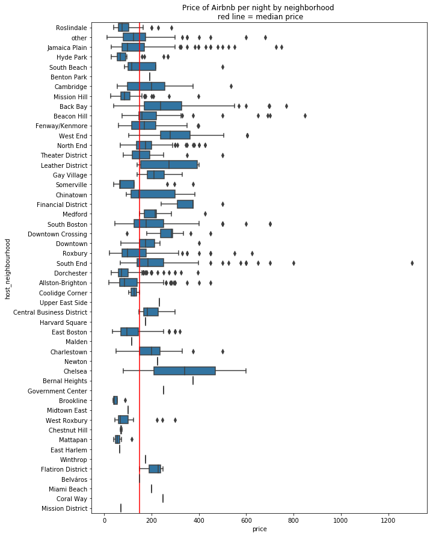

```python
plt.figure(figsize=(10,15))
base_color = sns.color_palette()[0]
sns.boxplot(data=listings_ss,x='price',y='host_neighbourhood',color=base_color)
plt.title('Price of Airbnb per night by neighborhood \n red line = median price')
#plt.axvline(listings_ss.price.mean())
plt.axvline(listings_ss.price.median(),color='r');
```

No surprises, some neighborhoods tend to be more expensive than others. Here are 8 sample

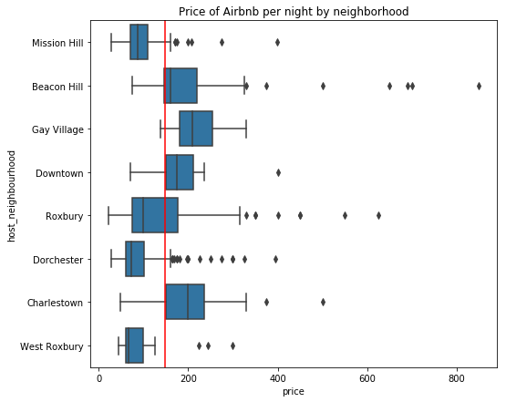

```python
plt.figure(figsize=(8,7))
base_color = sns.color_palette()[0]
sns.boxplot(data=listings_ss[listings_ss.host_neighbourhood.isin(nhoods)],x='price',y='host_neighbourhood',color=base_color)
plt.title('Price of Airbnb per night by neighborhood')
#plt.axvline(listings_ss.price.mean())
plt.axvline(listings_ss.price.median(),color='r');
```

While Beacon HIll 's median price is not much higher than the median price for the entire Boston area, it has many outliers, with some costing even >800 USD per night!

### What features are correlated with price?

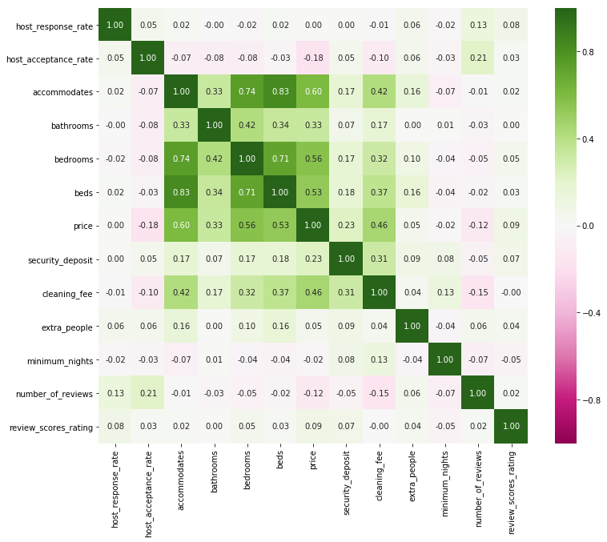

```python
plt.figure(figsize=(12,10))
sns.heatmap(listings_ss.loc[:,listings_ss.columns != 'id'].corr(),annot=True,vmin = -1, vmax =1,fmt='.2f',cmap='PiYG');
```

The element most correlated to price is how many people can be accommodated. No surpise there. Perhaps more surprisingly is the fact that # of reviews is negatively correlated with price as well as the host acceptance rate

### What is the impact on price of these dimensions?

```python
X2 = sm.add_constant(X)
est = sm.OLS(y, X2)
est2 = est.fit()
print(est2.summary())
```

```
                            OLS Regression Results
==============================================================================
Dep. Variable:                  price   R-squared:                       0.533
Model:                            OLS   Adj. R-squared:                  0.527
Method:                 Least Squares   F-statistic:                     91.75
Date:                Mon, 12 Aug 2019   Prob (F-statistic):               0.00
Time:                        19:24:42   Log-Likelihood:                -14529.
No. Observations:                2529   AIC:                         2.912e+04
Df Residuals:                    2497   BIC:                         2.931e+04
Df Model:                          31
Covariance Type:            nonrobust
=========================================================================================================
                                            coef    std err          t      P>|t|      [0.025      0.975]
---------------------------------------------------------------------------------------------------------
const                                    11.1170      7.912      1.405      0.160      -4.399      26.633
host_response_rate                        0.0555      0.206      0.270      0.787      -0.348       0.459
host_acceptance_rate                     -0.2183      0.083     -2.630      0.009      -0.381      -0.055
accommodates                             23.2750      1.034     22.501      0.000      21.247      25.303
number_of_reviews                        -0.1673      0.042     -3.953      0.000      -0.250      -0.084
review_scores_rating                      0.8852      0.178      4.985      0.000       0.537       1.233
cleaning_fee                              0.2269      0.036      6.245      0.000       0.156       0.298
extra_people                              0.0152      0.079      0.194      0.846      -0.139       0.170
minimum_nights                           -0.2955      0.221     -1.336      0.182      -0.729       0.138
host_response_time_a few days or more    12.5580     15.979      0.786      0.432     -18.776      43.892
host_response_time_within a day         -12.7963      6.255     -2.046      0.041     -25.062      -0.531
host_response_time_within a few hours    11.2655      6.660      1.691      0.091      -1.795      24.326
host_response_time_within an hour         0.0898      7.408      0.012      0.990     -14.437      14.617
host_is_superhost_f                      -2.6688      3.972     -0.672      0.502     -10.458       5.120
host_is_superhost_t                      13.7858      5.077      2.715      0.007       3.830      23.742
host_identity_verified_f                  5.2538      4.424      1.188      0.235      -3.421      13.929
host_identity_verified_t                  5.8632      4.358      1.345      0.179      -2.682      14.409
property_type_Apartment                 -14.2315     11.481     -1.240      0.215     -36.745       8.282
property_type_Bed & Breakfast            -7.9328     17.826     -0.445      0.656     -42.889      27.023
property_type_Boat                        2.0131     24.155      0.083      0.934     -45.352      49.379
property_type_Condominium                -0.8260     12.574     -0.066      0.948     -25.483      23.831
property_type_Dorm                      -18.9405     50.756     -0.373      0.709    -118.468      80.587
property_type_Entire Floor              -38.4941     70.723     -0.544      0.586    -177.175     100.187
property_type_Guesthouse                 45.0688     70.715      0.637      0.524     -93.597     183.734
property_type_House                     -14.1605     11.836     -1.196      0.232     -37.370       9.049
property_type_Loft                        8.4934     17.477      0.486      0.627     -25.778      42.765
```

[output cut: 9 more lines]

```
cancellation_policy_moderate            -13.2382      4.267     -3.102      0.002     -21.606      -4.870
cancellation_policy_strict              -17.9546      3.883     -4.624      0.000     -25.569     -10.340
cancellation_policy_super_strict_30      63.2468      8.263      7.655      0.000      47.045      79.449
host_neighbourhood_Allston-Brighton     -23.3211      5.385     -4.331      0.000     -33.881     -12.761
==============================================================================
Omnibus:                     1496.714   Durbin-Watson:                   1.801
Prob(Omnibus):                  0.000   Jarque-Bera (JB):            32955.880
Skew:                           2.371   Prob(JB):                         0.00
Kurtosis:                      20.037   Cond. No.                     2.34e+16
==============================================================================

Warnings:
[1] Standard Errors assume that the covariance matrix of the errors is correctly specified.
[2] The smallest eigenvalue is 1.32e-25. This might indicate that there are
strong multicollinearity problems or that the design matrix is singular.
```

```python
ols_results = est2.params.to_frame()
ols_results.rename(columns={0:"coefficient"},inplace=True)
ols_results['p_value']  = est2.pvalues.values
ols_results[ols_results.p_value <= 0.05]
```

|  | coefficient | p_value |
| --- | --- | --- |
| host_acceptance_rate | -0.218263 | 8.603101e-03 |
| accommodates | 23.275047 | 3.076365e-102 |
| number_of_reviews | -0.167254 | 7.922181e-05 |
| review_scores_rating | 0.885187 | 6.629713e-07 |
| cleaning_fee | 0.226906 | 4.957768e-10 |
| host_response_time_within a day | -12.796254 | 4.088584e-02 |
| host_is_superhost_t | 13.785771 | 6.667715e-03 |
| property_type_Other | 76.855107 | 5.136011e-03 |
| room_type_Entire home/apt | 50.392810 | 6.966563e-23 |
| room_type_Private room | -17.874960 | 1.641549e-04 |
| room_type_Shared room | -21.400839 | 9.956915e-03 |
| instant_bookable_f | 10.718554 | 1.725783e-02 |
| cancellation_policy_flexible | -20.937021 | 2.199348e-06 |
| cancellation_policy_moderate | -13.238168 | 1.942243e-03 |
| cancellation_policy_strict | -17.954627 | 3.963706e-06 |
| cancellation_policy_super_strict_30 | 63.246828 | 2.750355e-14 |
| host_neighbourhood_Allston-Brighton | -23.321096 | 1.546183e-05 |

This are the variables that are statistically significant :)

Some tokens of wisdom to extract here:

> If a place can host one additional person, you can expect a price increase of 23$.

> If review rating goes 1 percentage point up, you can expect an increase of 0.89 usd in the price per night. Is this much? Let's imagine you're renting a place 100 nights in a year. Your increase your score by 11 points (say, from 0.8 to 0.91) . This means that you can expect to gain 1000 USD more in that same year!

> Don't want to share an apartment with others? If you have the property all for yourself, you can expect the price to increase 50 USD